# Lab 07 - Word Clouds and Networks - Key

PSC-012Y

YOUR NAME HERE

11/21/2024

# Part 1. Coding and Visualization

## 1. Create a `list()` called `book` and assign it **all** of the Harry Potter books as in this week’s Virtual Tutorial [1pts]

```r
book = list(
  book.1 = philosophers_stone,
  book.2 = chamber_of_secrets,
  book.3 = prisoner_of_azkaban,
  book.4 = goblet_of_fire,
  book.5 = order_of_the_phoenix,
  book.6 = half_blood_prince,
  book.7 = deathly_hallows
)
```

## 2. Following the Virtual Tutorial script, organize your Corpus and show the last **10** words using the `tail()` function. Be sure to change the arguments in `tail()` to display 10-words! [1pts]

```r
  hp.words = book %>%
    ldply(function(texts, book_name){
      tibble(chapter = seq_along(texts), text = texts)
    }, .id = "book") %>%
    unnest_tokens(word, text, token = "words")
# Last 6 words in HP Series
  tail(hp.words, n = 10)
```

|  | book | chapter | word |
| --- | --- | --- | --- |
| 1089418 | book.7 | 37 | had |
| 1089419 | book.7 | 37 | not |
| 1089420 | book.7 | 37 | pained |
| 1089421 | book.7 | 37 | harry |
| 1089422 | book.7 | 37 | for |
| 1089423 | book.7 | 37 | nineteen |
| 1089424 | book.7 | 37 | years |
| 1089425 | book.7 | 37 | all |
| 1089426 | book.7 | 37 | was |
| 1089427 | book.7 | 37 | well |

## 3. Filter out stop words from the `book` corpus include names such as `"Harry"`, `"Ron"`. and `"Hermione"` [1pts]

```r
our.stops = data.frame(word = c("harry", "hermione", "ron", "weasley", "hagrid"))
all.stops = bind_rows(stop_words, our.stops)
# Do the Filtering
  hp.filtered = hp.words %>%
    anti_join(all.stops, by = "word")
  head(hp.filtered)
```

|  | book | chapter | word |
| --- | --- | --- | --- |
| 1 | book.1 | 1 | boy |
| 2 | book.1 | 1 | lived |
| 3 | book.1 | 1 | dursley |
| 4 | book.1 | 1 | privet |
| 5 | book.1 | 1 | drive |
| 6 | book.1 | 1 | proud |

## 4. Select the book you’d like to visualize as a word cloud and `subset()` the corpus to include that book. Create the wordcloud using the function: `wordcloud2()` [1pts]

**Note**: You may not select the 6th book for this visualization!

```r
book.pick = "book.2"
words.in.book = subset(hp.filtered, book == book.pick)
counts = as.data.frame(table(words.in.book$word))
colnames(counts) = c("word", "freq")
counts = counts[order(counts$freq, decreasing = TRUE),]
wordcloud2(data = counts)
```

[interactive chart not shown]

## 5. The code below loads in a social network called “Zachary’s karate club” and saves it into an variable called `karate`. Use the `plot()` function to visualize the karate club members. You do not need to apply any layout or additional functions for this [1pts]

```r
data("karate")
```

Plot goes below

```
## This graph was created by an old(er) igraph version.
## ℹ Call `igraph::upgrade_graph()` on it to use with the current igraph version.
## For now we convert it on the fly...
```

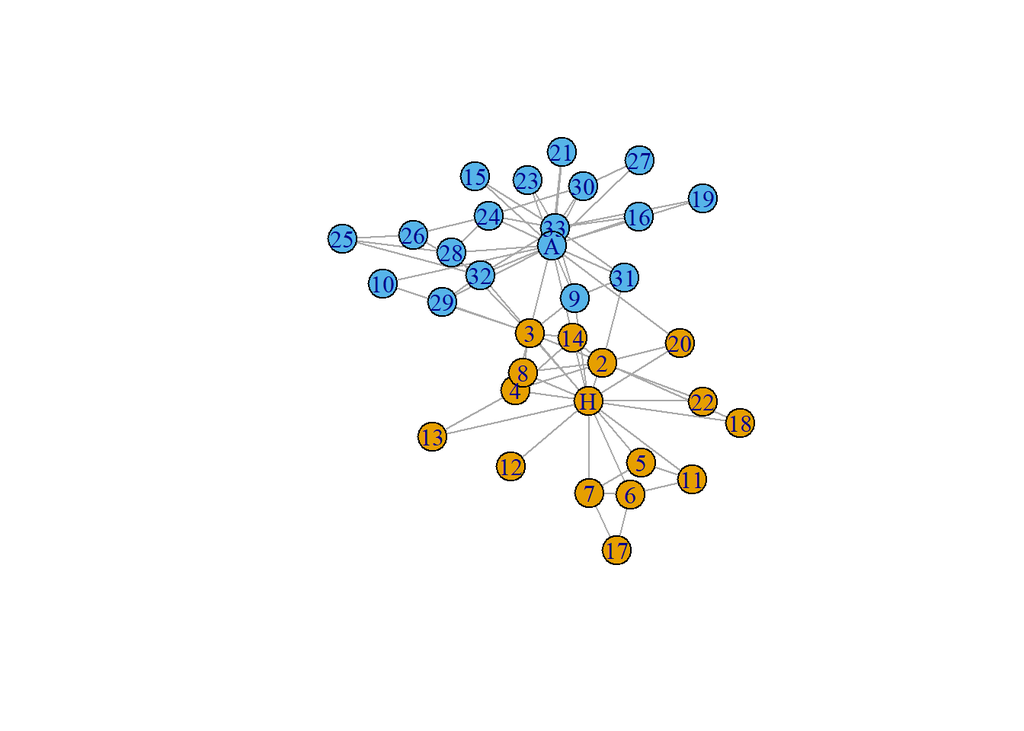

```r
plot(karate)
```

## 6. Calculate global metrics of the network [3pts]

- Density
- Average Path Length
- Diameter

```r
# Density
  edge_density(karate)
```

```
## [1] 0.1390374
```

```r
# Average Path Length
  mean_distance(karate)
```

```
## [1] 5.754011
```

```r
# Diameter
  diameter(karate)
```

```
## [1] 13
```

## 7. Calculate local metrics of the network (e.g., centrailty measures) [1pts]

- Degree
- Closeness
- Betweenness

```r
# Degree
  degree(karate)
```

```
##    Mr Hi  Actor 2  Actor 3  Actor 4  Actor 5  Actor 6  Actor 7  Actor 8
##       16        9       10        6        3        4        4        4
##  Actor 9 Actor 10 Actor 11 Actor 12 Actor 13 Actor 14 Actor 15 Actor 16
##        5        2        3        1        2        5        2        2
## Actor 17 Actor 18 Actor 19 Actor 20 Actor 21 Actor 22 Actor 23 Actor 24
##        2        2        2        3        2        2        2        5
## Actor 25 Actor 26 Actor 27 Actor 28 Actor 29 Actor 30 Actor 31 Actor 32
##        3        3        2        4        3        4        4        6
## Actor 33   John A
##       12       17
```

```r
# Closeness
  harmonic_centrality(karate)
```

```
##     Mr Hi   Actor 2   Actor 3   Actor 4   Actor 5   Actor 6   Actor 7   Actor 8
## 10.445238  8.243651  8.345671  6.561905  5.767460  5.600794  5.800794  6.735317
##   Actor 9  Actor 10  Actor 11  Actor 12  Actor 13  Actor 14  Actor 15  Actor 16
##  7.184524  7.868290  6.592857  5.211905  8.153571  6.784127  6.486147  5.026562
##  Actor 17  Actor 18  Actor 19  Actor 20  Actor 21  Actor 22  Actor 23  Actor 24
##  4.073121  7.777381  7.773449  9.683333  8.301587  6.775000  6.049206  5.036844
##  Actor 25  Actor 26  Actor 27  Actor 28  Actor 29  Actor 30  Actor 31  Actor 32
##  5.984127  4.584199  6.352814  6.063431  7.704762  6.594481  6.664358  7.735714
##  Actor 33    John A
##  8.451623 10.919444
```

```r
# Betweenness
  betweenness(karate)
```

```
##      Mr Hi    Actor 2    Actor 3    Actor 4    Actor 5    Actor 6    Actor 7
## 250.150000  33.800000  36.650000   1.333333   0.500000  15.500000  15.500000
##    Actor 8    Actor 9   Actor 10   Actor 11   Actor 12   Actor 13   Actor 14
##   0.000000  13.100000   7.283333   0.500000   0.000000   0.000000   1.200000
##   Actor 15   Actor 16   Actor 17   Actor 18   Actor 19   Actor 20   Actor 21
##   0.000000   0.000000   0.000000  16.100000   3.000000 127.066667   0.000000
##   Actor 22   Actor 23   Actor 24   Actor 25   Actor 26   Actor 27   Actor 28
##   0.000000   0.000000   1.000000  33.833333   0.500000   0.000000   6.500000
##   Actor 29   Actor 30   Actor 31   Actor 32   Actor 33     John A
##  10.100000   0.000000   3.000000  66.333333  38.133333 209.500000
```

## 8. Who has the highest degree? Closeness? Betweenness?

> They don’t need to have this exact code but they should identify who is the max as I provide you below:

```r
which(degree(karate) == max(degree(karate)))
```

```
## John A
##     34
```

```r
which(harmonic_centrality(karate) == max(harmonic_centrality(karate)))
```

```
## John A
##     34
```

```r
which(betweenness(karate) == max(betweenness(karate)))
```

```
## Mr Hi
##     1
```

# Part 2. Course Knowledge

## 1. Compare and contrast the 3 centrality measures for networks. How are they similar? How are they different? What do each tell us about a node in a network? Give an example in a work-environment of a person who has the highest `degree` and someone who has the highest `closeness`. Justify your answer [3pts]

> Degree tells us how many connections one has. Closeness has to do with individuals who are–approximately–closest to all other people. Betweenness is a measure of who all connections generally pass through.

> In a work environment, a recruiter may have the highest degree. They hire people and often interact with a lot of people. Closeness may be someone like management or a high-level executive. Someone who is involved with a lot of projects and people.

## 2. In a high school setting, the president of the associated students organization may have the highest `degree` due to their connections with other students. Does this automatically mean they are also the `closest` or highest in `betweenness`? Why or why not? [2pts]

> They aren’t guaranteed to have the highest closeness. Knowing more people (degree) doesn’t mean you necessarily are closer to people nor that you’re more integral to the functioning of the system/network.